# Capstone Exploratory Data Analysis

Performs the initial data analysis on the data set in order to see coorelations and possible paths forward

## Imports below

```python
import pandas as pd
import numpy as np
import matplotlib.pyplot as plt
import scipy.stats as st
import seaborn as sns
from sklearn.neighbors import KNeighborsClassifier
from sklearn.linear_model import LinearRegression
from sklearn.model_selection import train_test_split, cross_val_score, KFold
from sklearn import metrics
```

## Reads in the data

Reads it in and looks at the initial structure

```python
landslides = pd.read_csv('./data/Global_Landslide_Catalog_Export.csv')
```

```python
landslides.shape
```

```
(11033, 31)
```

```python
landslides.info()
```

```
<class 'pandas.core.frame.DataFrame'>
RangeIndex: 11033 entries, 0 to 11032
Data columns (total 31 columns):
 #   Column                     Non-Null Count  Dtype
---  ------                     --------------  -----
 0   source_name                11033 non-null  object
 1   source_link                10187 non-null  object
 2   event_id                   11033 non-null  int64
 3   event_date                 11033 non-null  object
 4   event_time                 0 non-null      float64
 5   event_title                11033 non-null  object
 6   event_description          10171 non-null  object
 7   location_description       10931 non-null  object
 8   location_accuracy          11031 non-null  object
 9   landslide_category         11032 non-null  object
```

[output cut: 23 more lines]

## Looks at some categories

Dummifies one of the categories to take a look at if there is coorelation

```python
landslides['landslide_category'].value_counts()

category_dummies_df = pd.get_dummies(landslides['landslide_category'])

landslides = pd.concat([landslides, category_dummies_df], axis=1)

category_dummies_df
```

|  | complex | creep | debris_flow | earth_flow | lahar | landslide | mudslide | other | riverbank_collapse | rock_fall | snow_avalanche | topple | translational_slide | unknown |
| --- | --- | --- | --- | --- | --- | --- | --- | --- | --- | --- | --- | --- | --- | --- |
| 0 | 0 | 0 | 0 | 0 | 0 | 1 | 0 | 0 | 0 | 0 | 0 | 0 | 0 | 0 |
| 1 | 0 | 0 | 0 | 0 | 0 | 0 | 1 | 0 | 0 | 0 | 0 | 0 | 0 | 0 |
| 2 | 0 | 0 | 0 | 0 | 0 | 1 | 0 | 0 | 0 | 0 | 0 | 0 | 0 | 0 |
| 3 | 0 | 0 | 0 | 0 | 0 | 1 | 0 | 0 | 0 | 0 | 0 | 0 | 0 | 0 |
| 4 | 0 | 0 | 0 | 0 | 0 | 1 | 0 | 0 | 0 | 0 | 0 | 0 | 0 | 0 |
| ... | ... | ... | ... | ... | ... | ... | ... | ... | ... | ... | ... | ... | ... | ... |
| 11028 | 0 | 0 | 0 | 0 | 0 | 1 | 0 | 0 | 0 | 0 | 0 | 0 | 0 | 0 |
| 11029 | 0 | 0 | 0 | 0 | 0 | 1 | 0 | 0 | 0 | 0 | 0 | 0 | 0 | 0 |
| 11030 | 0 | 0 | 0 | 0 | 0 | 1 | 0 | 0 | 0 | 0 | 0 | 0 | 0 | 0 |
| 11031 | 0 | 0 | 0 | 0 | 0 | 0 | 0 | 0 | 0 | 0 | 0 | 0 | 1 | 0 |
| 11032 | 0 | 0 | 0 | 0 | 0 | 0 | 1 | 0 | 0 | 0 | 0 | 0 | 0 | 0 |

11033 rows × 14 columns

```python
landslides['landslide_trigger'].value_counts()
```

```
downpour                   4680
rain                       2592
unknown                    1691
continuous_rain             748
tropical_cyclone            561
snowfall_snowmelt           135
monsoon                     129
mining                       93
earthquake                   89
construction                 82
flooding                     75
no_apparent_trigger          44
freeze_thaw                  41
other                        26
dam_embankment_collapse      12
leaking_pipe                 10
volcano                       1
vibration                     1
Name: landslide_trigger, dtype: int64
```

```python
landslides['landslide_size'].value_counts()
```

```
medium          6551
small           2767
unknown          851
large            750
very_large       102
catastrophic       3
Name: landslide_size, dtype: int64
```

```python
landslides['landslide_setting'].value_counts()
```

```
unknown             6291
above_road          3104
natural_slope        531
urban                264
below_road           199
mine                 157
above_river          149
deforested_slope      53
other                 50
retaining_wall        48
bluff                 48
burned_area           28
engineered_slope      22
above_coast           20
Name: landslide_setting, dtype: int64
```

```python
landslides['admin_division_name'].value_counts()
```

```
Oregon               948
Washington           407
California           400
Kashmir              204
Uttarakhand          189
                    ...
Gujarat                1
Volta                  1
Ōita                   1
Muḩāfaz̧at Ta‘izz      1
Gümüşhane              1
Name: admin_division_name, Length: 887, dtype: int64
```

```python
landslides['country_name'].value_counts()
```

```
United States    2992
India            1265
Philippines       675
Nepal             481
China             426
                 ...
Egypt               1
Jordan              1
Mauritius           1
Barbados            1
Gabon               1
Name: country_name, Length: 141, dtype: int64
```

```python
landslides['gazeteer_closest_point'].value_counts()
```

```
Niterói                 48
Waldport                47
Rio de Janeiro          45
Kohima                  44
Uttarkāshi              39
                        ..
Archidona                1
Aromas                   1
Paso Real de Sarabia     1
Cái Răng                 1
Pompei                   1
Name: gazeteer_closest_point, Length: 4389, dtype: int64
```

## Replaces the Nans

Makes the missing data easier to work with

Replaces the string values with unknown, the unknown string is already in the columns, so this will already be present in the column

```python
landslides['gazeteer_distance'].fillna(0.01, inplace=True)
```

```python
landslides['admin_division_population'].fillna(0, inplace=True)
```

```python
landslides['fatality_count'].fillna(0, inplace=True)
```

```python
landslides['injury_count'].fillna(0, inplace=True)
```

```python
landslides['gazeteer_closest_point'].fillna('unknown', inplace=True)
```

```python
landslides['landslide_category'].fillna('unknown', inplace=True)
```

```python
landslides['landslide_trigger'].fillna('unknown', inplace=True)
```

```python
landslides['landslide_size'].fillna('unknown', inplace=True)
```

```python
landslides['landslide_setting'].fillna('unknown', inplace=True)
```

```python
landslides['country_name'].fillna('unknown', inplace=True)
```

```python
landslides['admin_division_name'].fillna('unknown', inplace=True)
```

### Makes new columns

Makes the population a function of distance from the nearest gazeteer location. A gazeteer is a directory / dictionary of locations on a map.

I did this to simulate population density of the area.

If gazeteer distance is less than 1 then it is fixed to one, so that a small distance won't result in an $\infty$ population

$$fixed population = \frac{admindivisionpopulation}{gazeteerdistance}$$

Also combines the fatality and injury counts so there is just one casualties column

```python
landslides['r_distance_multiplier'] = np.where((1 / landslides['gazeteer_distance']) > 1, 1, 1 / landslides['gazeteer_distance'])
```

```python
landslides['r_distance_multiplier'].describe()
```

```
count    11033.000000
mean         0.402279
std          0.384909
min          0.004641
25%          0.074025
50%          0.218088
75%          0.901974
max          1.000000
Name: r_distance_multiplier, dtype: float64
```

```python
landslides['fixed_population'] = landslides['admin_division_population'] * landslides['r_distance_multiplier']
```

```python
landslides['fixed_population'].describe()
```

```
count    1.103300e+04
mean     5.027915e+04
std      4.071393e+05
min      0.000000e+00
25%      2.277227e+01
50%      6.981164e+02
75%      5.493739e+03
max      1.229419e+07
Name: fixed_population, dtype: float64
```

```python
landslides['casualties'] = landslides['injury_count'] + landslides['fatality_count']
```

## Looks at the data again

Takes the info with the dummied columns

```python
landslides.info()
```

```
<class 'pandas.core.frame.DataFrame'>
RangeIndex: 11033 entries, 0 to 11032
Data columns (total 48 columns):
 #   Column                     Non-Null Count  Dtype
---  ------                     --------------  -----
 0   source_name                11033 non-null  object
 1   source_link                10187 non-null  object
 2   event_id                   11033 non-null  int64
 3   event_date                 11033 non-null  object
 4   event_time                 0 non-null      float64
 5   event_title                11033 non-null  object
 6   event_description          10171 non-null  object
 7   location_description       10931 non-null  object
 8   location_accuracy          11031 non-null  object
 9   landslide_category         11033 non-null  object
```

[output cut: 40 more lines]

## Tries some initial model making

The null hypothesis is 76.4%, this means that if you were to predict 0 for all values it would be 76.4% correct.

First tries a K Nearest Neighbor because to try to see if there is some thing there.

Then tries a cross validation with linear regression, it looks like the cross validation score is about 0.

```python
casualty_free = landslides[landslides['casualties'] == 0].count()['casualties']
null_hypothesis = casualty_free/11033

print(f'The percentage of zeros in the casualties column is {null_hypothesis*100:.2f}%')
```

```
The percentage of zeros in the casualties column is 76.40%
```

```python
X_list = category_dummies_df.columns.tolist() + [ 'fixed_population', 'longitude', 'latitude']
X = landslides[X_list]
y = landslides['casualties']
X_train, X_test, y_train, y_test = train_test_split(X, y, shuffle=True)
X_train
```

|  | complex | creep | debris_flow | earth_flow | lahar | landslide | mudslide | other | riverbank_collapse | rock_fall | snow_avalanche | topple | translational_slide | unknown | fixed_population | longitude | latitude |
| --- | --- | --- | --- | --- | --- | --- | --- | --- | --- | --- | --- | --- | --- | --- | --- | --- | --- |
| 3677 | 0 | 0 | 0 | 0 | 0 | 1 | 0 | 0 | 0 | 0 | 0 | 0 | 0 | 0 | 928.283142 | -122.5437 | 45.3310 |
| 7498 | 0 | 0 | 0 | 0 | 0 | 1 | 0 | 0 | 0 | 0 | 0 | 0 | 0 | 0 | 2344.000000 | -122.8422 | 46.0100 |
| 1759 | 0 | 0 | 0 | 0 | 0 | 1 | 0 | 0 | 0 | 0 | 0 | 0 | 0 | 0 | 0.000000 | 100.7451 | 6.7077 |
| 985 | 0 | 0 | 0 | 0 | 0 | 0 | 0 | 0 | 0 | 1 | 0 | 0 | 0 | 0 | 1849.000000 | -73.9215 | 40.9522 |
| 9292 | 0 | 0 | 0 | 0 | 0 | 0 | 1 | 0 | 0 | 0 | 0 | 0 | 0 | 0 | 18088.987562 | -90.1993 | 38.8980 |
| ... | ... | ... | ... | ... | ... | ... | ... | ... | ... | ... | ... | ... | ... | ... | ... | ... | ... |
| 6370 | 1 | 0 | 0 | 0 | 0 | 0 | 0 | 0 | 0 | 0 | 0 | 0 | 0 | 0 | 401270.000000 | 2.6500 | 39.5667 |
| 689 | 0 | 0 | 0 | 0 | 0 | 1 | 0 | 0 | 0 | 0 | 0 | 0 | 0 | 0 | 624.156590 | 91.2000 | 25.8833 |
| 1909 | 0 | 0 | 0 | 0 | 0 | 1 | 0 | 0 | 0 | 0 | 0 | 0 | 0 | 0 | 96913.938541 | 79.1492 | 18.4310 |
| 9173 | 0 | 0 | 0 | 0 | 0 | 0 | 1 | 0 | 0 | 0 | 0 | 0 | 0 | 0 | 437.627496 | -120.6609 | 38.3139 |
| 9791 | 0 | 0 | 0 | 0 | 0 | 0 | 1 | 0 | 0 | 0 | 0 | 0 | 0 | 0 | 132.308335 | -120.5001 | 46.9085 |

8274 rows × 17 columns

```python
knn = KNeighborsClassifier(n_neighbors=3)
knn.fit(X_train, y_train)
```

```
KNeighborsClassifier(n_neighbors=3)
```

```python
y_pred_class = knn.predict(X_test)
print(metrics.accuracy_score(y_test, y_pred_class))
```

```
0.7451975353388909
```

```python
knn.score(X_test, y_test)
```

```
0.7451975353388909
```

```python
scores = []
for k in range(1,50):
    X_train, X_test, y_train, y_test = train_test_split(X, y, shuffle=True)
    knn = KNeighborsClassifier(n_neighbors=k)
    knn.fit(X_train,y_train)
    score = knn.score(X_test, y_test)
    scores.append([k, score])
```

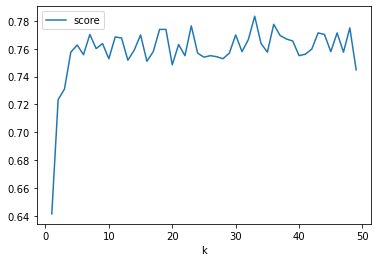

```python
data = pd.DataFrame(scores,columns=['k','score'])
data.plot.line(x='k',y='score');
```

```python
lr = LinearRegression()

lr.fit(X_train, y_train)
test_score = lr.score(X_test, y_test)


cvs = cross_val_score(LinearRegression(), X, y, cv=KFold(3, shuffle=True))

print(f'Linear regression might not work the score on the test set is {test_score:.2f},\n\
and with cross validation is mean: {cvs.mean():.2f}, max: {cvs.max():.2f}, and min: {cvs.min():.2f}')
```

```
Linear regression might not work the score on the test set is -0.26,
and with cross validation is mean: -0.06, max: 0.00, and min: -0.16
```

### Shows some coorelation

Uses the seaborn library to try to find some kind of coorelation in the columns

```python
pairs = category_dummies_df.columns.tolist() + ['casualties', 'fixed_population', 'longitude', 'latitude']
landslides[pairs]
```

|  | complex | creep | debris_flow | earth_flow | lahar | landslide | mudslide | other | riverbank_collapse | rock_fall | snow_avalanche | topple | translational_slide | unknown | casualties | fixed_population | longitude | latitude |
| --- | --- | --- | --- | --- | --- | --- | --- | --- | --- | --- | --- | --- | --- | --- | --- | --- | --- | --- |
| 0 | 0 | 0 | 0 | 0 | 0 | 1 | 0 | 0 | 0 | 0 | 0 | 0 | 0 | 0 | 11.0 | 0.000000 | 107.450000 | 32.562500 |
| 1 | 0 | 0 | 0 | 0 | 0 | 0 | 1 | 0 | 0 | 0 | 0 | 0 | 0 | 0 | 0.0 | 36619.000000 | -122.663000 | 45.420000 |
| 2 | 0 | 0 | 0 | 0 | 0 | 1 | 0 | 0 | 0 | 0 | 0 | 0 | 0 | 0 | 10.0 | 14708.000000 | -75.358700 | -11.129500 |
| 3 | 0 | 0 | 0 | 0 | 0 | 1 | 0 | 0 | 0 | 0 | 0 | 0 | 0 | 0 | 1.0 | 20908.000000 | 81.708000 | 28.837800 |
| 4 | 0 | 0 | 0 | 0 | 0 | 1 | 0 | 0 | 0 | 0 | 0 | 0 | 0 | 0 | 0.0 | 394964.491306 | 123.897800 | 10.333600 |
| ... | ... | ... | ... | ... | ... | ... | ... | ... | ... | ... | ... | ... | ... | ... | ... | ... | ... | ... |
| 11028 | 0 | 0 | 0 | 0 | 0 | 1 | 0 | 0 | 0 | 0 | 0 | 0 | 0 | 0 | 27.0 | 0.000000 | 111.679944 | -7.853409 |
| 11029 | 0 | 0 | 0 | 0 | 0 | 1 | 0 | 0 | 0 | 0 | 0 | 0 | 0 | 0 | 2.0 | 0.000000 | 75.680611 | 33.403080 |
| 11030 | 0 | 0 | 0 | 0 | 0 | 1 | 0 | 0 | 0 | 0 | 0 | 0 | 0 | 0 | 1.0 | 0.000000 | 91.772042 | 26.181606 |
| 11031 | 0 | 0 | 0 | 0 | 0 | 0 | 0 | 0 | 0 | 0 | 0 | 0 | 1 | 0 | 24.0 | 0.000000 | 73.472379 | 40.886395 |
| 11032 | 0 | 0 | 0 | 0 | 0 | 0 | 1 | 0 | 0 | 0 | 0 | 0 | 0 | 0 | 2.0 | 0.000000 | 78.356505 | 17.465630 |

11033 rows × 18 columns

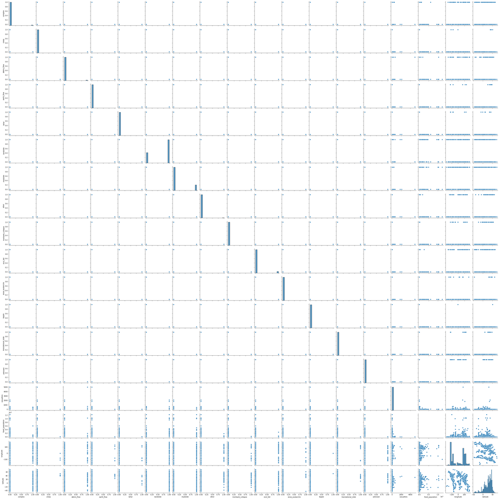

```python
sns.pairplot(landslides[pairs]);
```

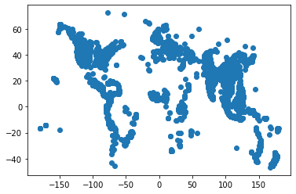

```python
plt.scatter(landslides['longitude'], landslides['latitude'])
```

## Conclusions

I don't see any coorelations in the data, from the inital models and seaborn.

If I'm going to move forward, I'll probably need to undersample, which can cause other problems with the data.